# Hands-on workshop: Dose-response modelling for AOPs

# 1 Preperation

## 1.1 Set Working Directory (WD)

R is always pointed at a directory on your computer. By default,

- R loads files (Plain text files / Data files etc.) from this directory.
- R outputs files (Plain text files / Data files etc.) to this directory.
- Set **W**orking **D**irectory (WD)
  - **On Windows**
    - in R interface choose : `Menu - File - Change dir...`
    - Choose a local directory (folder)
      - for example I use `C:/Users/Admin/Documents/Konstanz_summer_school/Day2` (actrually Day 3) as my working directory

[figure not shown]

[figure not shown]

  - **On MacOs**
    - in R insterface choose : `menu - Misc - Change Working Directory...`
      - for example I use `~/Documents/Konstanz_summer_school/Day2` as my working directory

[figure not shown]

[figure not shown]

  - **Verify your WD**
    - type `getwd()` in R console prompt: after `>`, then press `enter` key
    - R should print your current **WD**

## 1.2 Download dataset and load it to R

Copy - Paste in R console prompt: after `>`, then press `enter` key

```r
tmpData = readLines("https://antoinechn.github.io/Konstanz-SummerSchool/data/data_GSH.txt")
writeLines(tmpData, "data_GSH.txt")
rm(tmpData)
```

- once this is done, type `list.files()` in R console prompt: after `>`, then press `enter` key
- R should print all files in your working directory. Check if `data_GSH.txt` is listed
- if still not
  - check your internet connection !!!
  - or contact us.

```r
list.files()
```

## 1.3 Load data

This is `GSH` (after 1h)

```r
data_GSH = read.table("data_GSH.txt", sep="\t", header=TRUE)

head(data_GSH)
```

```
#>   KBrO3_mM group pct_control
#> 1    0.000     1   91.521770
#> 2    0.375     1   63.591550
#> 3    0.750     1   50.508870
#> 4    1.500     1   14.285990
#> 5    3.000     1    2.477166
#> 6    6.000     1    0.377906
```

**Try this**

```r
data_GSH = read.table("https://trello-attachments.s3.amazonaws.com/59552633a56853b5f6d1f1f9/5a92760183331b90626ce166/678efebfc21386538df65c23120fc741/data_GSH.txt", sep="\t", header=TRUE)

head(data_GSH)
```

**Try this**

```r
data_GSH = read.table("https://antoinechn.github.io/Konstanz-SummerSchool/data/data_GSH.txt", sep="\t", header=TRUE)

head(data_GSH)
```

# 2 Data visualisation using `plot()`

Plot the data to get a sense of it

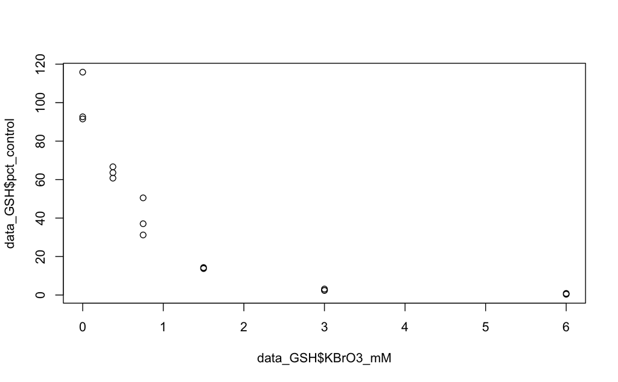

```r
plot(data_GSH$KBrO3_mM, data_GSH$pct_control)
```

**You have plenty of options, the most useful are:**

```r
# nicer
plot(data_GSH$KBrO3_mM, data_GSH$pct_control, las=1)
# professional
plot(data_GSH$KBrO3_mM, data_GSH$pct_control, las=1,
     xlab="KBrO3 (mM)", ylab="GSH decrease (%)")
# excellent
plot(data_GSH$KBrO3_mM, data_GSH$pct_control, las=1,
     xlab="KBrO3 (mM)", ylab="GSH decrease (%)", main="My Beautiful Data")
# clever
plot(data_GSH$KBrO3_mM, data_GSH$pct_control, las=1,
     xlab="KBrO3 (mM)", ylab="GSH decrease (%)", main="My Beautiful Data",
     log="y") # you can use log="x" or "y" or "xy" or ""
# genius level
plot(data_GSH$KBrO3_mM, data_GSH$pct_control, las=1,
     xlab="KBrO3 (mM)", ylab="GSH decrease (%)", main="My Beautiful Data",
     log="y", pch=10, cex= 1.3, col="red") # set the type of mark, size, color

# etc. see help(par) or ?par for all the parameters you can set
```

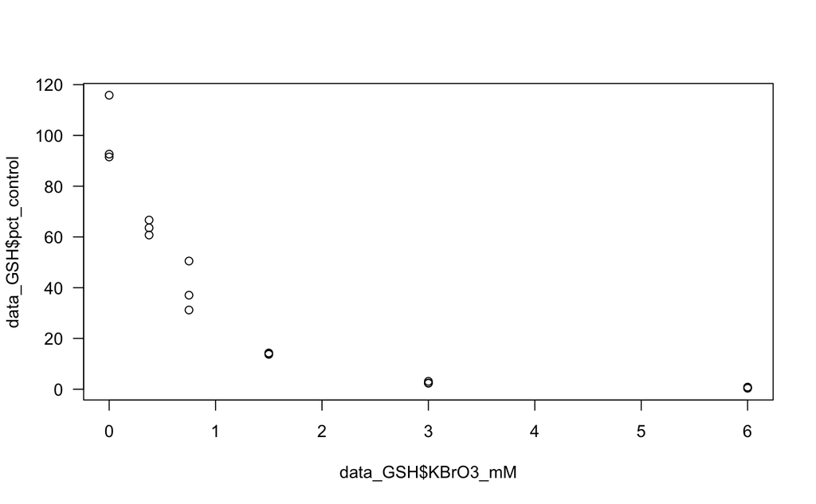

```r
# nicer
plot(data_GSH$KBrO3_mM, data_GSH$pct_control, las=1)
```

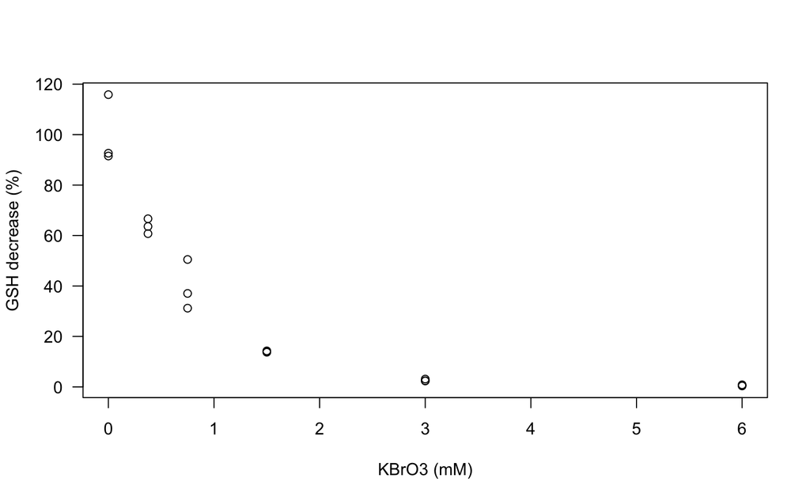

```r
# professional
plot(data_GSH$KBrO3_mM, data_GSH$pct_control, las=1,
     xlab="KBrO3 (mM)", ylab="GSH decrease (%)")
```

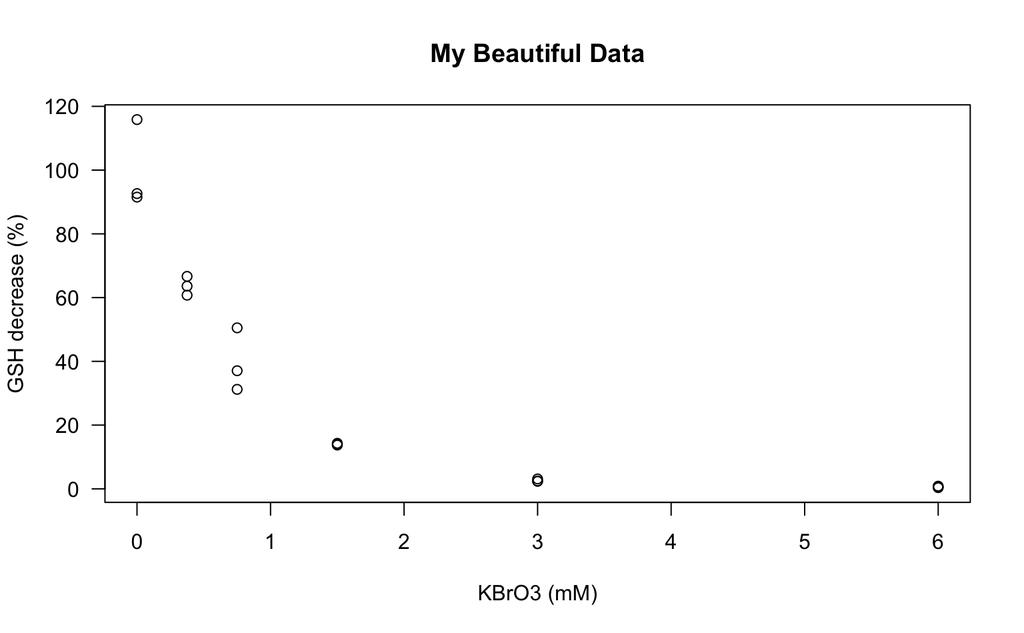

```r
# excellent
plot(data_GSH$KBrO3_mM, data_GSH$pct_control, las=1,
     xlab="KBrO3 (mM)", ylab="GSH decrease (%)", main="My Beautiful Data")
```

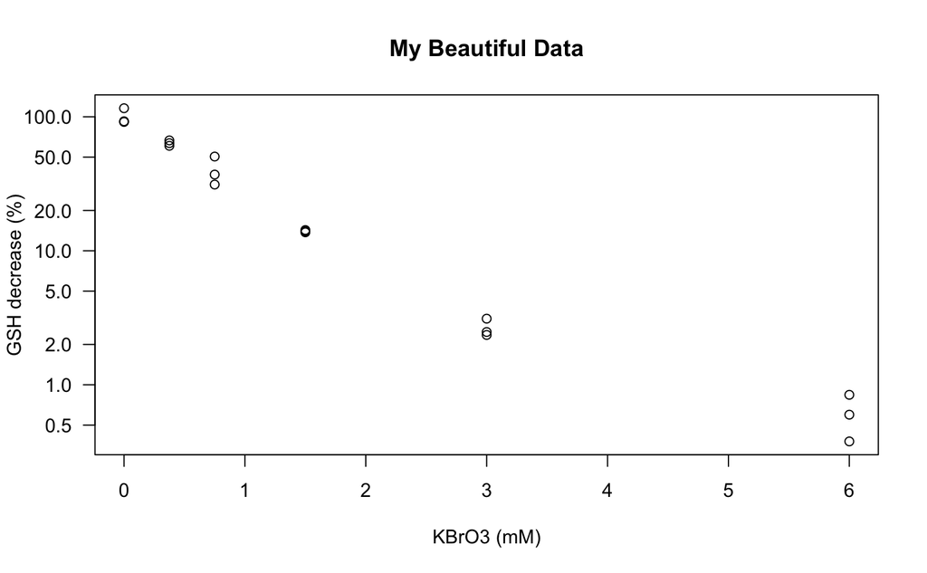

```r
# clever
plot(data_GSH$KBrO3_mM, data_GSH$pct_control, las=1,
     xlab="KBrO3 (mM)", ylab="GSH decrease (%)", main="My Beautiful Data",
     log="y") # you can use log="x" or "y" or "xy" or ""
```

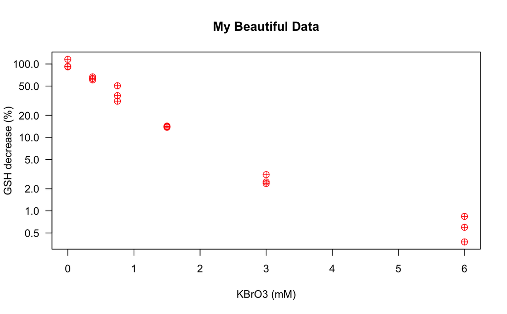

```r
# genius level
plot(data_GSH$KBrO3_mM, data_GSH$pct_control, las=1,
     xlab="KBrO3 (mM)", ylab="GSH decrease (%)", main="My Beautiful Data",
     log="y", pch=10, cex= 1.3, col="red") # set the type of mark, size, color
```

# 3 Modelling

## 3.1 Hill dose-response model

Let’s get serious:

- define the Hill dose-response model as a function
- let’s try it
- plot it…

```r
# define the Hill dose-response model as a function
Hill = function (x, EC50, n) {
  return(x^n / (x^n + EC50^n))
}

# let's try it
Hill(x=10, EC50=1, n=1)

# plot it...
x = seq(0, 10, 0.1)
y = Hill(x=x, EC50=1, n=3)
plot(x, y, type="b")
```

```r
# define the Hill dose-response model as a function
Hill = function (x, EC50, n) {
  return(x^n / (x^n + EC50^n))
}
# let's try it
Hill(x=10, EC50=1, n=1)
```

```
#> [1] 0.9090909
```

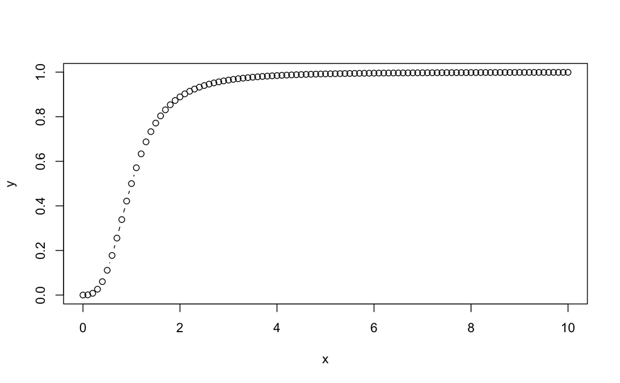

```r
# plot it...
x = seq(0, 10, 0.1)
y = Hill(x=x, EC50=1, n=3)
plot(x, y, type="b")
```

**Problem:**

- it goes up from zero to one
- and we want it to go down from 100 to 0

## 3.2 Extended Hill dose-response model

**So we change it a bit**

- define an extended Hill dose-response model as a function
- try it…
- plot it…

```r
# define an extended Hill dose-response model as a function
Hill = function (x, EC50, n, from, diff) {
  return(from + diff * (x^n / (x^n + EC50^n)))
}

# try it
Hill(x=10, EC50=1, n=1, from=1, diff=10)

# plot it...
x = seq(0, 10, 0.1)
y = Hill(x=x, EC50=1, n=3, from=1, diff=10)
plot(x, y, type="b")
```

```r
# define an extended Hill dose-response model as a function
Hill = function (x, EC50, n, from, diff) {
  return(from + diff * (x^n / (x^n + EC50^n)))
}

# try it
Hill(x=10, EC50=1, n=1, from=1, diff=10)
```

```
#> [1] 10.09091
```

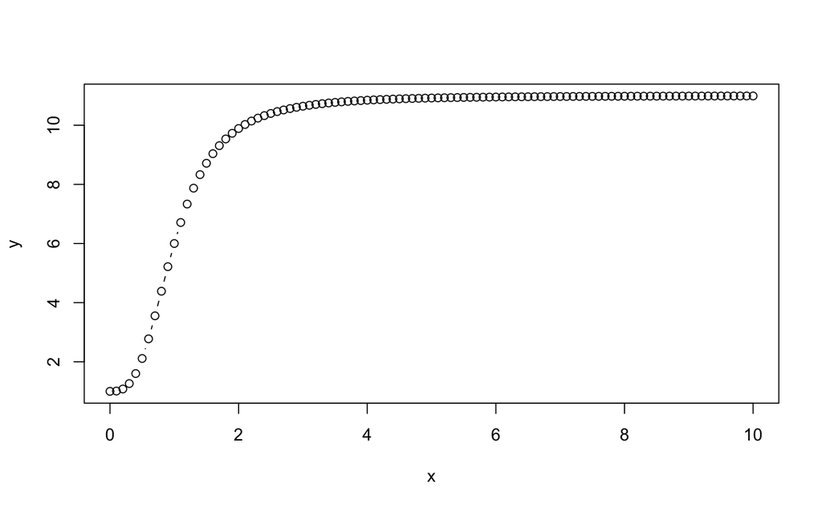

```r
# plot it...
x = seq(0, 10, 0.1)
y = Hill(x=x, EC50=1, n=3, from=1, diff=10)
plot(x, y, type="b")
```

**Question**

- Can you find values of from and diff that would match the data range?
  - first: what is the data range?
  - assign the values found to variables A and B

```r
# assign the values found to variables A and B
A =
B =
```

**now replot the data and overlay with the model**

Note : make sure to define the axes limits before doing overlays…

```r
xlims = c(0, 6) # a vector of min and max
ylims = c(0, 120)
plot(data_GSH$KBrO3_mM, data_GSH$pct_control, xlim=xlims, ylim=ylims, col="red")
par(new=T) # will overlay the next plot
x = seq(0, 6, 0.1)
y = Hill(x=x, EC50=1, n=3, from=A, diff=B)
plot(x, y, type="l", xlim=xlims, ylim=ylims, xlab="", ylab="") # turn off labels
```

**now play with EC50 and N to fit the data better**

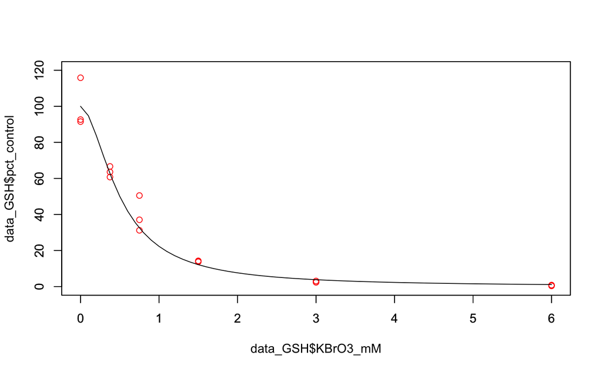

- `A = 100`
- `B = -100`
- `EC50 = 0.5`
- `n = 1.8`

## 3.3 Inverting the Hill dose-reponse model

- Can you code a function inverting the Hill dose-response model?
- Plot the function you found.

$$y = A + B \times \frac{x^n}{x^n+ {EC_{50}}^n}$$

$$x = \;?$$

```r
invs.hill = function(y, EC50, A, B, n){
   YOUR CODE HERE
  }
```

Some calculations

$$x =\; \sqrt[n]{ \frac{{EC_{50}}^n} {\frac{B}{y-A} -1} }$$

R function

```r
invs.hill = function(y, EC50, A, B, n){
    res = (EC50 ^n /(B/(y-A)  - 1 ) )^(1/n)
    return(res)
  }
```

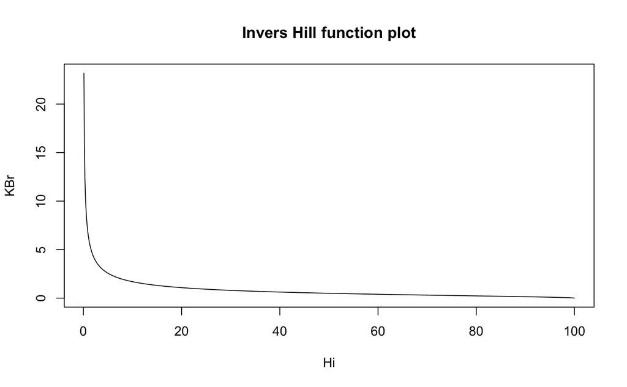

```r
# A = 100
# B = -100
# EC50 = 0.5
# n = 1.8

Hi = seq(0.1, 100, by = 0.1)
KBr = invs.hill(y = Hi,
                EC50 = 0.5,
                A = 100,
                B = -100,
                n = 1.8)

plot(x = Hi, y = KBr, type = 'l',
     main = "Invers Hill function plot")
```

## 3.4 Notes

There are many tools in R that can be used to fit automatically your model one of them is PROAST (from the RIVM) but we can also access PROAST online (more fun)

## 3.5 Visit the three following links

https://www.rivm.nl/en/Documents_and_publications/Scientific/Models/PROAST

https://proastweb.rivm.nl

https://www.epa.gov/bmds

Back to home